# data summary report

2025-03-10

[output not shown]

This report provides an overview of the dataset from the **Monts Uapishka** project, focusing on four key aspects:  
1. Data Completeness: Assessment of missing or incomplete data. (project)  
2. Data Summary: Summary statistics and descriptive insights into the dataset. (project-species)  
3. site-level data summary and scale issues (site-species)  
4. Correlation Analysis and quality assessment code: Evaluation of autocorrelation and correlation with the mean chronology for each series. It includes quality assessment codes generated by the CFS_qa() function. (radii-species)

The report aims to provide a comprehensive overview of the dataset’s quality and characteristics, analyzed at the levels of species, species-site, and species-radius.

### data completeness

This table presents the completeness of each variable of the whole dataset as a percentage. A value of 0 indicates no effective data. Please carefully verify that all required data has been included in the submission.

| var | pct |
| --- | --- |
| tr1_submission_id | 100 |
| tr1_project_name | 100 |
| tr1_description | 0 |
| tr1_year_range | 100 |
| tr1_reference | 0 |
| tr1_open_data | 100 |
| tr1_contact1 | 0 |
| tr1_contact2 | 0 |
| tr2_site_id | 100 |
| tr2_latitude | 100 |
| tr2_longitude | 100 |
| tr2_datasource | 0 |
| tr2_investigators | 0 |

| var | pct |
| --- | --- |
| tr2_province_iso_code | 0 |
| tr3_tree_id | 100 |
| tr3_species | 100 |
| tr4_meas_no | 0 |
| tr4_meas_date | 100 |
| tr4_status | 0 |
| tr4_dbh_cm | 0 |
| tr4_ht_tot_m | 0 |
| tr5_sample_id | 100 |
| tr5_sample_type | 0 |
| tr5_sample_ht_m | 0 |
| tr5_sample_diameter_cm | 0 |

| var | pct |
| --- | --- |
| tr6_radius_id | 100 |
| tr6_cofecha_id | 0 |
| tr6_ring_meas_method | 0 |
| tr6_crossdating_visual | 0 |
| tr6_crossdating_validation | 0 |
| tr6_age_corrected | 0 |
| tr6_bark_thickness_mm | 0 |
| tr6_radius_inside_cm | 0 |
| tr6_dtc_measured_mm | 0 |
| tr6_dtc_estimated_mm | 0 |
| tr6_rw_ystart | 100 |
| tr6_rw_yend | 100 |
| tr6_comments | 0 |

### data summary

This section presents key summary statistics, including spatial and temporal ranges, summary of ring width measurements, series length, etc. categorized by species.

In this dataset, there’re 4 species: **SAB, EPN, BOP, EPB**

Progress pair-wise ccf…

[1] “1 N.pass: 20” [1] “2 N.pass: 20” [1] “3 N.pass: 22”

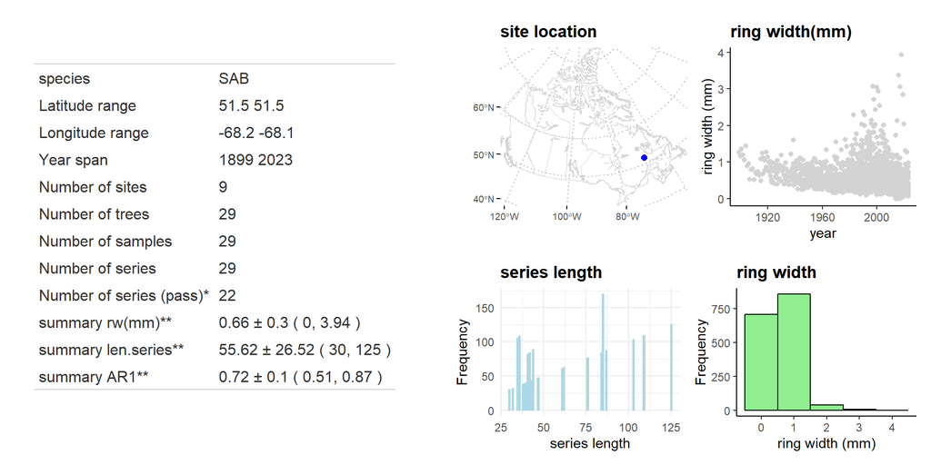

Progress pair-wise ccf…

[1] “1 N.pass: 25” [1] “2 N.pass: 19” [1] “3 N.pass: 18”

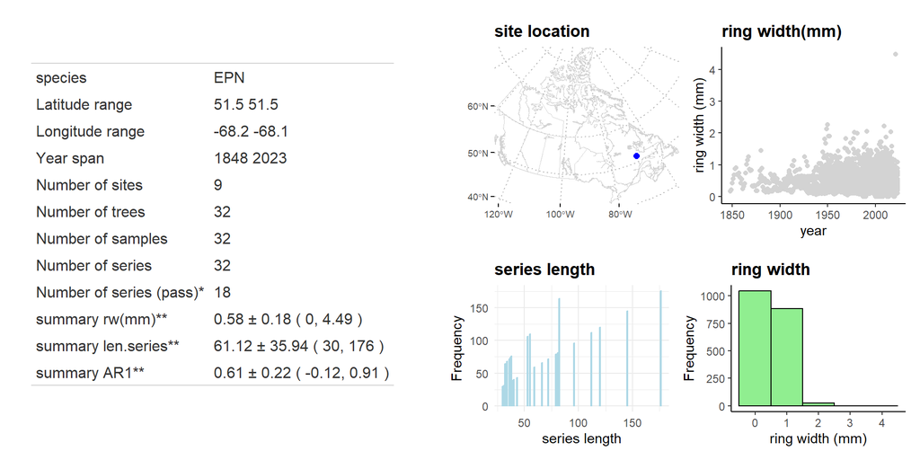

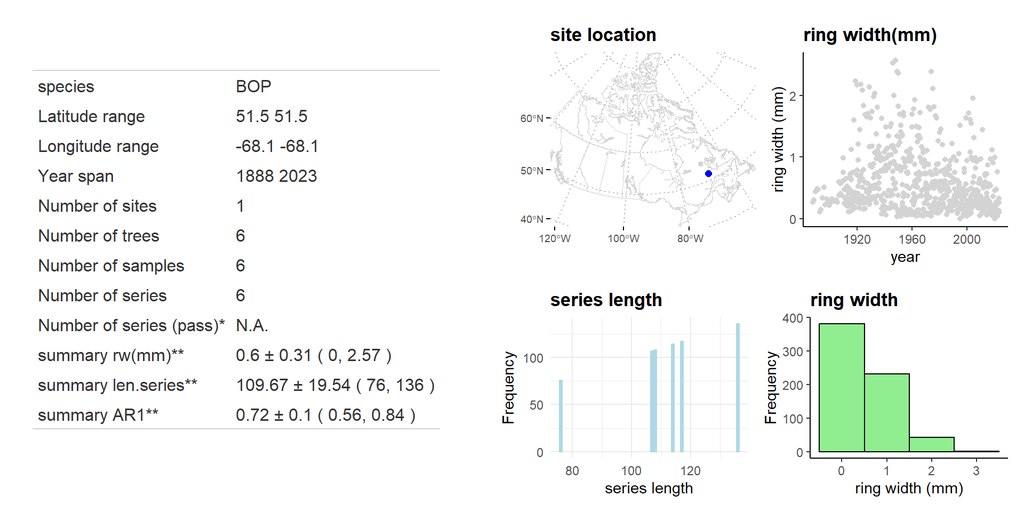

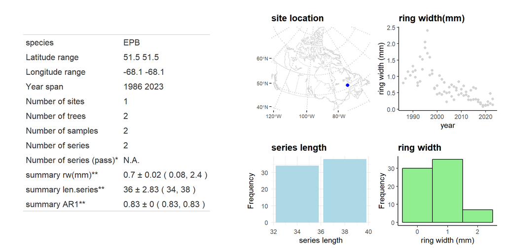

*Number of series that passed the test of CFS_qa() on differentiated series

**The values refer to mean ± sd (min, max)

### site-level data summary

This section presents site-level data summaries, including a figure showing ring width measurements over time and a table with key statistics.

##### SAB on ring width measurement

[1] 6

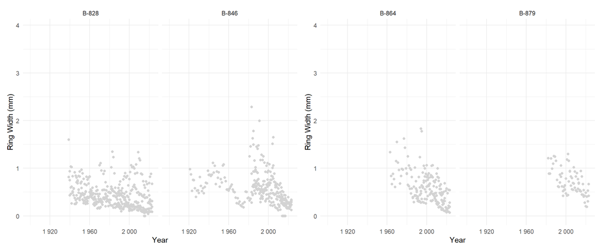

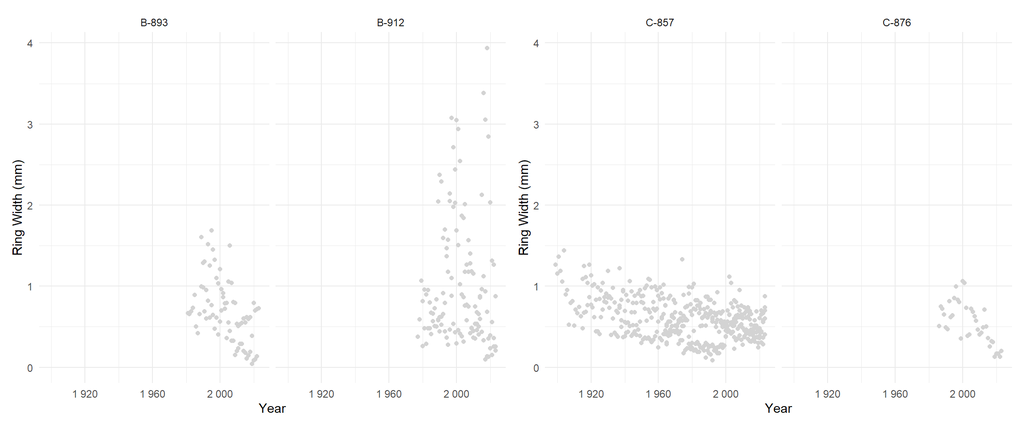

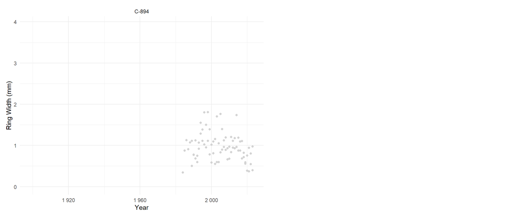

##### EPN on ring width measurement

[1] 6

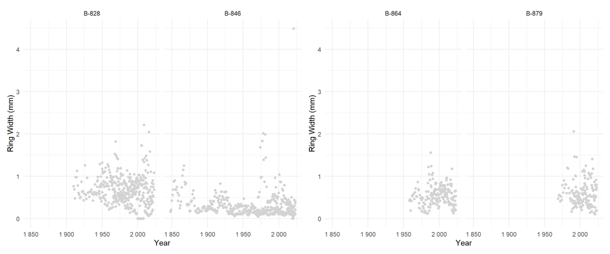

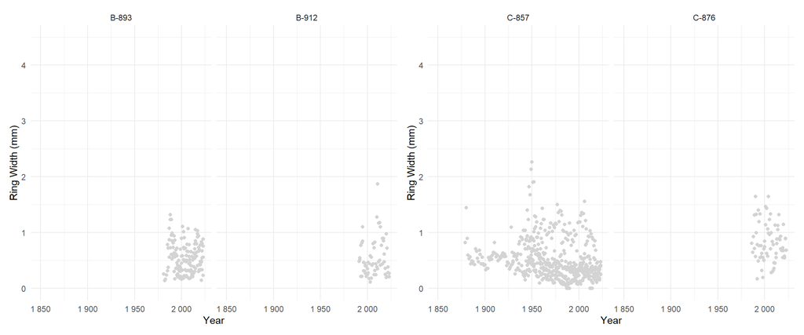

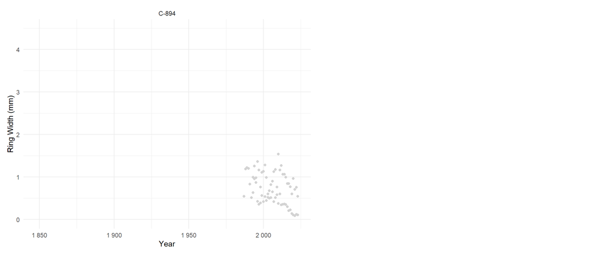

##### BOP on ring width measurement

[1] 2

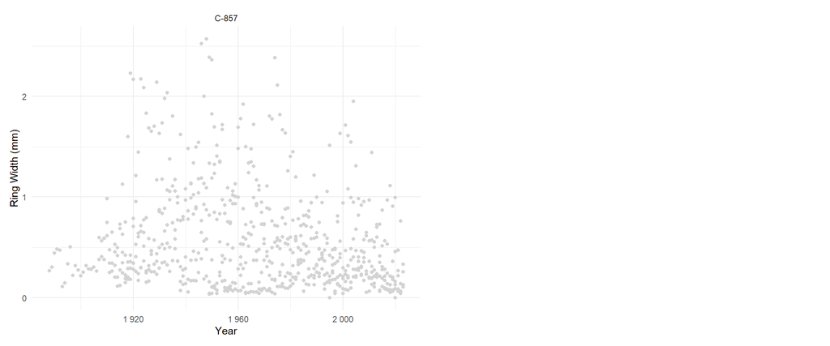

##### EPB on ring width measurement

[1] 2

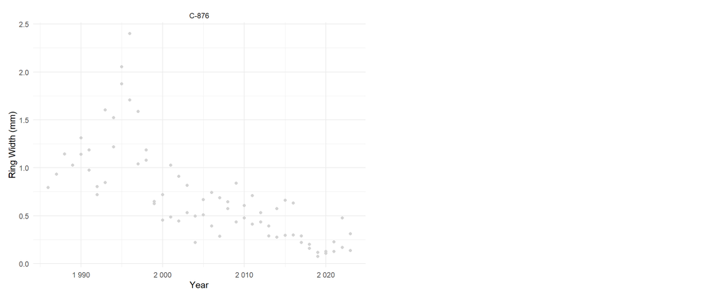

This table provides a site-level summary, including the series length, raw ring width measurements, the median ring width, the median ring width of its10 closest neighbors, and the ratio between them. This offers insights into potential outliers caused by scaling issues.

[1] 1

SAB

| uid_site | site_id | lon | lat | species | Nb. trees | len.series** | rw(mm)** | median rw(mm) | neigh median rw(mm) | ratio_rw* |
| --- | --- | --- | --- | --- | --- | --- | --- | --- | --- | --- |
| 1 | B-828 | -68.16508 | 51.48351 | SAB | 5 | 73.2 ± 21.14 ( 36, 85 ) | 0.48 ± 0.2 ( 0, 1.6 ) | 0.34350 | 0.64725 | 0.5 |
| 2 | B-846 | -68.16420 | 51.48408 | SAB | 5 | 53.4 ± 27.76 ( 39, 103 ) | 0.58 ± 0.16 ( 0, 2.28 ) | 0.49700 | 0.64725 | 0.8 |
| 3 | B-864 | -68.16340 | 51.48466 | SAB | 4 | 43.25 ± 12.84 ( 32, 61 ) | 0.6 ± 0.09 ( 0.07, 1.83 ) | 0.56425 | 0.64725 | 0.9 |
| 4 | B-879 | -68.16290 | 51.48498 | SAB | 2 | 36 ± 8.49 ( 30, 42 ) | 0.7 ± 0.1 ( 0.19, 1.3 ) | 0.65000 | 0.56425 | 1.2 |
| 5 | B-893 | -68.16238 | 51.48521 | SAB | 2 | 38.5 ± 4.95 ( 35, 42 ) | 0.71 ± 0.32 ( 0.04, 1.69 ) | 0.64725 | 0.56425 | 1.1 |
| 6 | B-912 | -68.16181 | 51.48551 | SAB | 3 | 42 ± 6.24 ( 35, 47 ) | 1.09 ± 0.68 ( 0.1, 3.94 ) | 0.82500 | 0.56425 | 1.5 |
| 7 | C-857 | -68.14553 | 51.47722 | SAB | 5 | 83.8 ± 35.72 ( 36, 125 ) | 0.58 ± 0.15 ( 0.09, 1.44 ) | 0.64600 | 0.65000 | 1.0 |
| 8 | C-876 | -68.14598 | 51.47790 | SAB | 1 | 38 ± NA ( 38, 38 ) | 0.55 ± NA ( 0.13, 1.06 ) | 0.50600 | 0.65000 | 0.8 |
| 9 | C-894 | -68.14606 | 51.47838 | SAB | 2 | 37.5 ± 3.54 ( 35, 40 ) | 0.96 ± 0.13 ( 0.34, 1.81 ) | 0.93425 | 0.64725 | 1.4 |

[1] 2

EPN

| uid_site | site_id | lon | lat | species | Nb. trees | len.series** | rw(mm)** | median rw(mm) | neigh median rw(mm) | ratio_rw* |
| --- | --- | --- | --- | --- | --- | --- | --- | --- | --- | --- |
| 1 | B-828 | -68.16508 | 51.48351 | EPN | 5 | 76 ± 22.79 ( 55, 112 ) | 0.7 ± 0.18 ( 0, 2.21 ) | 0.74600 | 0.54025 | 1.4 |
| 2 | B-846 | -68.16420 | 51.48408 | EPN | 4 | 94.75 ± 66.27 ( 30, 176 ) | 0.43 ± 0.2 ( 0, 4.49 ) | 0.31975 | 0.55275 | 0.6 |
| 3 | B-864 | -68.16340 | 51.48466 | EPN | 4 | 48.75 ± 13.6 ( 36, 66 ) | 0.56 ± 0.1 ( 0.12, 1.55 ) | 0.55275 | 0.54025 | 1.0 |
| 4 | B-879 | -68.16290 | 51.48498 | EPN | 4 | 40.25 ± 10.14 ( 32, 55 ) | 0.58 ± 0.1 ( 0.1, 2.06 ) | 0.49525 | 0.55275 | 0.9 |
| 5 | B-893 | -68.16238 | 51.48521 | EPN | 4 | 38.25 ± 3.77 ( 34, 43 ) | 0.55 ± 0.16 ( 0.14, 1.32 ) | 0.62375 | 0.54025 | 1.2 |
| 6 | B-912 | -68.16181 | 51.48551 | EPN | 2 | 32.5 ± 0.71 ( 32, 33 ) | 0.53 ± 0.17 ( 0.11, 1.87 ) | 0.54025 | 0.55275 | 1.0 |
| 7 | C-857 | -68.14553 | 51.47722 | EPN | 5 | 96.6 ± 27.88 ( 79, 145 ) | 0.48 ± 0.24 ( 0, 2.26 ) | 0.44000 | 0.62375 | 0.7 |
| 8 | C-876 | -68.14598 | 51.47790 | EPN | 2 | 36 ± 2.83 ( 34, 38 ) | 0.82 ± 0.01 ( 0.17, 1.65 ) | 0.76125 | 0.54025 | 1.4 |
| 9 | C-894 | -68.14606 | 51.47838 | EPN | 2 | 34 ± 4.24 ( 31, 37 ) | 0.7 ± 0.15 ( 0.09, 1.53 ) | 0.66400 | 0.54025 | 1.2 |

[1] 3

BOP

| uid_site | site_id | lon | lat | species | Nb. trees | len.series** | rw(mm)** |
| --- | --- | --- | --- | --- | --- | --- | --- |
| 7 | C-857 | -68.14553 | 51.47722 | BOP | 6 | NA ± NA ( NA, NA ) | NA ± NA ( NA, NA ) |

[1] 4

EPB

| uid_site | site_id | lon | lat | species | Nb. trees | len.series** | rw(mm)** |
| --- | --- | --- | --- | --- | --- | --- | --- |
| 8 | C-876 | -68.14598 | 51.4779 | EPB | 2 | NA ± NA ( NA, NA ) | NA ± NA ( NA, NA ) |

*ratio between median of rw of the site and median of rw of its 10 nearest neighbors.

**The values refer to mean ± sd (min, max)

### Correlation and quality assessment code

This table provides a summary for each series, including raw ring width measurements, autocorrelation, correlation with master chronology for both raw and differentiated data, and quality assessment code (qa_code) which was derived from the CFS_qa() function. The master chronology includes all the series with qa_code ‘pass’.

SAB

| uid_site | uid_radius | year from | year to | len series | raw AR1* | raw corr_mean*& | trt AR1** | trt corr_mean**& | qa_code**% |
| --- | --- | --- | --- | --- | --- | --- | --- | --- | --- |
| 1 | 1 | 1947 | 2022 | 76 | 0.87 | 0.1 ( 75, 0.41 ) | 0.01 | 0.31 ( 75, 0.01 ) | pass |
| 1 | 2 | 1940 | 2023 | 84 | 0.76 | 0.31 ( 83, 0 ) | -0.15 | 0.38 ( 83, 0 ) | pass |
| 1 | 3 | 1988 | 2023 | 36 | 0.63 | 0.09 ( 35, 0.62 ) | -0.15 | 0.27 ( 35, 0.12 ) | pass |
| 1 | 4 | 1939 | 2023 | 85 | 0.76 | 0.37 ( 84, 0 ) | -0.05 | 0.21 ( 84, 0.06 ) | Fail |
| 1 | 5 | 1939 | 2023 | 85 | 0.54 | 0.36 ( 84, 0 ) | -0.12 | 0.53 ( 84, 0 ) | pass |
| 2 | 11 | 1983 | 2023 | 41 | 0.76 | 0.62 ( 40, 0 ) | -0.34 | 0.4 ( 40, 0.01 ) | pass |
| 2 | 12 | 1983 | 2023 | 41 | 0.59 | 0.45 ( 40, 0 ) | -0.17 | -0.01 ( 40, 0.96 ) | Fail |
| 2 | 13 | 1981 | 2023 | 43 | 0.86 | 0.5 ( 42, 0 ) | -0.33 | 0.54 ( 42, 0 ) | pass |
| 2 | 14 | 1985 | 2023 | 39 | 0.78 | 0.86 ( 38, 0 ) | -0.09 | 0.61 ( 38, 0 ) | pass |
| 2 | 15 | 1921 | 2023 | 103 | 0.78 | 0.47 ( 102, 0 ) | -0.36 | 0.5 ( 102, 0 ) | pass |
| 3 | 20 | 1992 | 2023 | 32 | 0.78 | 0.66 ( 31, 0 ) | 0.00 | 0.39 ( 31, 0.03 ) | pass |
| 3 | 21 | 1988 | 2023 | 36 | 0.85 | 0.53 ( 35, 0 ) | 0.07 | 0.46 ( 35, 0.01 ) | pass |
| 3 | 22 | 1980 | 2023 | 44 | 0.77 | 0.53 ( 43, 0 ) | -0.01 | 0.42 ( 43, 0 ) | pass |
| 3 | 23 | 1963 | 2023 | 61 | 0.82 | 0.18 ( 60, 0.16 ) | 0.02 | 0.6 ( 60, 0 ) | pass |
| 4 | 28 | 1994 | 2023 | 30 | 0.81 | 0.81 ( 29, 0 ) | 0.22 | 0.35 ( 29, 0.06 ) | pass |
| 4 | 29 | 1982 | 2023 | 42 | 0.72 | 0.25 ( 41, 0.11 ) | -0.03 | 0.33 ( 41, 0.03 ) | pass |
| 5 | 34 | 1989 | 2023 | 35 | 0.73 | 0.75 ( 34, 0 ) | -0.35 | 0.56 ( 34, 0 ) | pass |
| 5 | 35 | 1981 | 2022 | 42 | 0.80 | 0.89 ( 41, 0 ) | -0.13 | 0.69 ( 41, 0 ) | pass |
| 6 | 40 | 1989 | 2023 | 35 | 0.78 | 0.31 ( 34, 0.07 ) | 0.12 | 0.43 ( 34, 0.01 ) | pass |
| 6 | 41 | 1980 | 2023 | 44 | 0.73 | 0.28 ( 43, 0.07 ) | -0.43 | -0.26 ( 43, 0.09 ) | Fail |
| 6 | 42 | 1977 | 2023 | 47 | 0.69 | 0.31 ( 46, 0.04 ) | -0.25 | -0.22 ( 46, 0.14 ) | Fail |
| 7 | 45 | 1937 | 2023 | 87 | 0.65 | -0.2 ( 86, 0.06 ) | -0.40 | 0.43 ( 86, 0 ) | pass |
| 7 | 46 | 1988 | 2023 | 36 | 0.51 | 0.51 ( 35, 0 ) | -0.12 | 0.53 ( 35, 0 ) | pass |
| 7 | 47 | 1899 | 2023 | 125 | 0.65 | 0.72 ( 124, 0 ) | -0.37 | 0.69 ( 124, 0 ) | pass |
| 7 | 48 | 1962 | 2023 | 62 | 0.59 | -0.12 ( 61, 0.36 ) | -0.12 | 0.46 ( 61, 0 ) | pass |
| 7 | 49 | 1915 | 2023 | 109 | 0.83 | 0.56 ( 108, 0 ) | -0.32 | 0.5 ( 108, 0 ) | pass |
| 8 | 61 | 1986 | 2023 | 38 | 0.65 | 0.66 ( 37, 0 ) | -0.17 | 0.05 ( 37, 0.79 ) | highpeak |
| 9 | 66 | 1984 | 2023 | 40 | 0.56 | 0.57 ( 39, 0 ) | -0.39 | 0.08 ( 39, 0.61 ) | Fail |
| 9 | 67 | 1989 | 2023 | 35 | 0.67 | -0.01 ( 34, 0.94 ) | -0.15 | -0.01 ( 34, 0.98 ) | Fail |

EPN

| uid_site | uid_radius | year from | year to | len series | raw AR1* | raw corr_mean*& | trt AR1** | trt corr_mean**& | qa_code**% |
| --- | --- | --- | --- | --- | --- | --- | --- | --- | --- |
| 1 | 6 | 1969 | 2023 | 55 | 0.76 | 0.24 ( 54, 0.08 ) | 0.02 | 0.12 ( 54, 0.38 ) | Fail |
| 1 | 7 | 1942 | 2023 | 82 | 0.78 | -0.27 ( 81, 0.02 ) | -0.08 | -0.13 ( 81, 0.26 ) | Fail |
| 1 | 8 | 1947 | 2018 | 72 | 0.75 | -0.3 ( 71, 0.01 ) | -0.17 | -0.11 ( 71, 0.38 ) | Fail |
| 1 | 9 | 1964 | 2022 | 59 | 0.42 | 0.12 ( 58, 0.37 ) | -0.22 | -0.15 ( 58, 0.26 ) | Fail |
| 1 | 10 | 1910 | 2021 | 112 | 0.45 | -0.38 ( 111, 0 ) | -0.45 | -0.17 ( 111, 0.07 ) | Fail |
| 2 | 16 | 1994 | 2023 | 30 | -0.12 | 0.31 ( 29, 0.1 ) | -0.49 | 0.55 ( 29, 0 ) | pass |
| 2 | 17 | 1848 | 2023 | 176 | 0.91 | 0.65 ( 175, 0 ) | 0.12 | 0.69 ( 175, 0 ) | pass |
| 2 | 18 | 1904 | 2023 | 120 | 0.84 | -0.11 ( 119, 0.22 ) | -0.38 | 0.39 ( 119, 0 ) | pass |
| 2 | 19 | 1971 | 2023 | 53 | 0.75 | 0.28 ( 52, 0.04 ) | -0.16 | 0.57 ( 52, 0 ) | pass |
| 3 | 24 | 1988 | 2023 | 36 | 0.39 | 0.38 ( 35, 0.02 ) | -0.52 | 0.6 ( 35, 0 ) | pass |
| 3 | 25 | 1984 | 2023 | 40 | 0.80 | 0.47 ( 39, 0 ) | -0.27 | 0.57 ( 39, 0 ) | pass |
| 3 | 26 | 1958 | 2023 | 66 | 0.45 | 0.05 ( 65, 0.72 ) | -0.23 | 0.05 ( 65, 0.71 ) | Fail |
| 3 | 27 | 1971 | 2023 | 53 | 0.57 | 0.48 ( 52, 0 ) | -0.31 | 0.58 ( 52, 0 ) | pass |
| 4 | 30 | 1986 | 2023 | 38 | 0.72 | 0.6 ( 37, 0 ) | -0.20 | 0.56 ( 37, 0 ) | pass |
| 4 | 31 | 1969 | 2023 | 55 | 0.62 | -0.16 ( 54, 0.26 ) | -0.20 | -0.04 ( 54, 0.79 ) | pm1 |
| 4 | 32 | 1992 | 2023 | 32 | 0.33 | -0.01 ( 31, 0.94 ) | -0.28 | -0.23 ( 31, 0.22 ) | pm1 |
| 4 | 33 | 1988 | 2023 | 36 | 0.64 | 0.14 ( 35, 0.41 ) | -0.16 | 0.55 ( 35, 0 ) | pass |
| 5 | 36 | 1990 | 2023 | 34 | 0.54 | 0.39 ( 33, 0.02 ) | -0.06 | 0.42 ( 33, 0.02 ) | pass |
| 5 | 37 | 1981 | 2023 | 43 | 0.67 | 0.37 ( 42, 0.02 ) | -0.14 | 0.06 ( 42, 0.68 ) | pm1 |
| 5 | 38 | 1985 | 2023 | 39 | 0.78 | 0.06 ( 38, 0.72 ) | -0.18 | -0.01 ( 38, 0.94 ) | Fail |
| 5 | 39 | 1987 | 2023 | 37 | 0.63 | 0.57 ( 36, 0 ) | -0.20 | 0.53 ( 36, 0 ) | pass |
| 6 | 43 | 1991 | 2023 | 33 | 0.24 | 0.47 ( 32, 0.01 ) | -0.31 | 0.5 ( 32, 0 ) | pass |
| 6 | 44 | 1992 | 2023 | 32 | 0.64 | 0.47 ( 31, 0.01 ) | -0.16 | 0.6 ( 31, 0 ) | pass |
| 7 | 56 | 1928 | 2023 | 96 | 0.49 | -0.21 ( 95, 0.04 ) | -0.29 | 0.08 ( 95, 0.47 ) | borderline |
| 7 | 57 | 1879 | 2023 | 145 | 0.84 | 0.65 ( 144, 0 ) | -0.23 | 0.66 ( 144, 0 ) | pass |
| 7 | 58 | 1943 | 2023 | 81 | 0.71 | 0.21 ( 80, 0.06 ) | -0.20 | 0.58 ( 80, 0 ) | pass |
| 7 | 59 | 1942 | 2023 | 82 | 0.62 | -0.01 ( 81, 0.9 ) | -0.50 | 0.31 ( 81, 0 ) | pass |
| 7 | 60 | 1945 | 2023 | 79 | 0.91 | -0.1 ( 78, 0.39 ) | -0.05 | 0.1 ( 78, 0.38 ) | Fail |
| 8 | 64 | 1989 | 2022 | 34 | 0.50 | 0.24 ( 33, 0.18 ) | -0.40 | 0.09 ( 33, 0.63 ) | pm1 |
| 8 | 65 | 1986 | 2023 | 38 | 0.55 | 0.44 ( 37, 0.01 ) | -0.24 | 0.32 ( 37, 0.05 ) | pass |
| 9 | 68 | 1993 | 2023 | 31 | 0.83 | 0.12 ( 30, 0.52 ) | -0.43 | -0.21 ( 30, 0.27 ) | Fail |
| 9 | 69 | 1987 | 2023 | 37 | 0.58 | 0.49 ( 36, 0 ) | -0.28 | 0.5 ( 36, 0 ) | pass |

BOP

| uid_site | uid_radius | year from | year to | len series | raw AR1* | raw corr_mean*& | trt AR1** | trt corr_mean**& | qa_code**% |
| --- | --- | --- | --- | --- | --- | --- | --- | --- | --- |
| 7 | 50 | NA | NA | NA | NA | NA ( NA, NA ) | NA | NA ( NA, NA ) | NA |
| 7 | 51 | NA | NA | NA | NA | NA ( NA, NA ) | NA | NA ( NA, NA ) | NA |
| 7 | 52 | NA | NA | NA | NA | NA ( NA, NA ) | NA | NA ( NA, NA ) | NA |
| 7 | 53 | NA | NA | NA | NA | NA ( NA, NA ) | NA | NA ( NA, NA ) | NA |
| 7 | 54 | NA | NA | NA | NA | NA ( NA, NA ) | NA | NA ( NA, NA ) | NA |
| 7 | 55 | NA | NA | NA | NA | NA ( NA, NA ) | NA | NA ( NA, NA ) | NA |

EPB

| uid_site | uid_radius | year from | year to | len series | raw AR1* | raw corr_mean*& | trt AR1** | trt corr_mean**& | qa_code**% |
| --- | --- | --- | --- | --- | --- | --- | --- | --- | --- |
| 8 | 62 | NA | NA | NA | NA | NA ( NA, NA ) | NA | NA ( NA, NA ) | NA |
| 8 | 63 | NA | NA | NA | NA | NA ( NA, NA ) | NA | NA ( NA, NA ) | NA |

*developed from raw series

**developed from differentiated series

&correlation with master chronology, the value represents correlation (N, p-value)

%qa_code is identified using the current data as reference dataset